# Making a grid of kmers

To make an image that summarize the distribution of k-mers for a sample, we will need to assign each kmer to a pixel. We used tSNE to place kmers in a 2D plane based on their sequence similarity. Here we will move kmers around as needed to assign each one uniquely to one pixel.

Let’s start by setting the kmer size, loading data and packages.

```r
rm(list=ls())
kmer_len = 9
library(tidyverse)
library(acss)
library(furrr)
library(arrow)
plan(multisession,workers = 4)
```

```r
tsne_res = read_csv(paste0('tsne_',kmer_len,'_result.csv'))
tsne_res
```

| V1 | V2 | r | t | AT | canonical | rc | complexity |
| --- | --- | --- | --- | --- | --- | --- | --- |
| -8.5166466 | -31.33111182 | 32.468013 | -1.836210371 | 1.0000000 | AAAAAAAAA | TTTTTTTTT | 21.95445 |
| -8.2667364 | -31.20527018 | 32.281695 | -1.829762401 | 0.8888889 | CAAAAAAAA | TTTTTTTTG | 22.91832 |
| -8.2592119 | -31.24151718 | 32.314810 | -1.829250072 | 0.8888889 | GAAAAAAAA | TTTTTTTTC | 22.91832 |
| -17.0624229 | -28.77992775 | 33.457593 | -2.105948127 | 1.0000000 | TAAAAAAAA | TTTTTTTTA | 22.91832 |
| -7.9910732 | -30.87064525 | 31.888148 | -1.824093175 | 0.8888889 | ACAAAAAAA | TTTTTTTGT | 23.62814 |
| -7.9860769 | -31.08660029 | 32.096014 | -1.822256356 | 0.7777778 | CCAAAAAAA | TTTTTTTGG | 23.99124 |
| -8.1123113 | -31.31779406 | 32.351411 | -1.824257480 | 0.7777778 | GCAAAAAAA | TTTTTTTGC | 24.13356 |
| -7.9314201 | -31.07173657 | 32.068056 | -1.820720887 | 0.8888889 | TCAAAAAAA | TTTTTTTGA | 24.13356 |
| -7.8289287 | -31.24478018 | 32.210688 | -1.816309105 | 0.8888889 | AGAAAAAAA | TTTTTTTCT | 23.62814 |
| -8.2447127 | -31.11254383 | 32.186421 | -1.829838712 | 0.7777778 | CGAAAAAAA | TTTTTTTCG | 24.13356 |

[output cut: 990 more lines]

Let’s visualize the distribution of kmers according to their AT richness

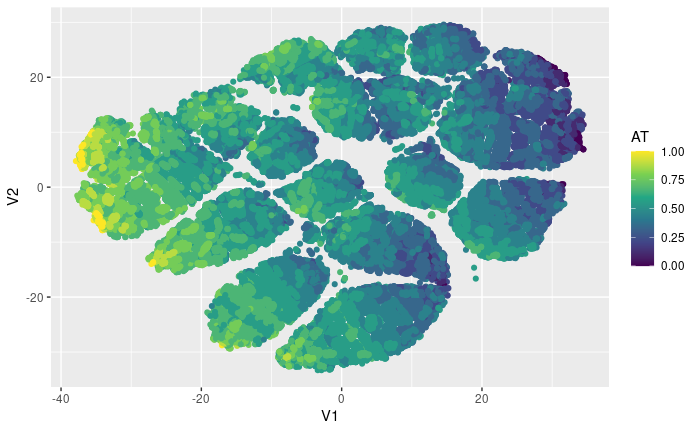

```r
ggplot(tsne_res) +
  geom_point(aes(x=V1, y=V2,color=AT)) +
  scale_color_viridis_c()
```

Now, let’s define a grid with sufficient size for all points:

```r
dimensions = ceiling(sqrt(nrow(tsne_res)))

pixels = expand.grid(list(x.min = 1:dimensions, y.min = 1:dimensions)) %>%
  mutate(x.mid=x.min+0.5,
         y.mid=y.min+0.5,
         x.max=x.min+1,
         y.max=y.min+1,
         pixel_ID = 1:n())

pixels
```

| x.min | y.min | x.mid | y.mid | x.max | y.max | pixel_ID |
| --- | --- | --- | --- | --- | --- | --- |
| 1 | 1 | 1.5 | 1.5 | 2 | 2 | 1 |
| 2 | 1 | 2.5 | 1.5 | 3 | 2 | 2 |
| 3 | 1 | 3.5 | 1.5 | 4 | 2 | 3 |
| 4 | 1 | 4.5 | 1.5 | 5 | 2 | 4 |
| 5 | 1 | 5.5 | 1.5 | 6 | 2 | 5 |
| 6 | 1 | 6.5 | 1.5 | 7 | 2 | 6 |
| 7 | 1 | 7.5 | 1.5 | 8 | 2 | 7 |
| 8 | 1 | 8.5 | 1.5 | 9 | 2 | 8 |
| 9 | 1 | 9.5 | 1.5 | 10 | 2 | 9 |
| 10 | 1 | 10.5 | 1.5 | 11 | 2 | 10 |

[output cut: 990 more lines]

As the first pass, let’s define within which grid cell each point is:

```r
find_grid = function(df) {
  pixels %>%
        filter(df$x < x.max, df$x > x.min,
               df$y < y.max, df$y > y.min) %>%
        pull(pixel_ID)
}

rescaled_tSNE = tsne_res %>%
  mutate(x = scales::rescale(tsne_res$V1,c(1.5,dimensions-0.5),range(tsne_res$V1)),
         y = scales::rescale(tsne_res$V2,c(1.5,dimensions-0.5),range(tsne_res$V2)))

rescaled_tSNE = rescaled_tSNE %>%
  mutate(pixel_ID = rescaled_tSNE %>%
           split(f = 1:nrow(.)) %>%
           furrr::future_map(~ pixels %>%
                 filter(pull(.x,x) < x.max, pull(.x,x) > x.min,
                        pull(.x,y) < y.max, pull(.x,y) > y.min) %>%
                 pull(pixel_ID)))
```

```r
rescaled_tSNE = tidyr::unnest(rescaled_tSNE,pixel_ID)

summary(as.vector(table(rescaled_tSNE$pixel_ID)))
```

```
   Min. 1st Qu.  Median    Mean 3rd Qu.    Max.
  1.000   1.000   3.000   3.684   5.000  53.000
```

Let’s visualize where we have areas of very high density:

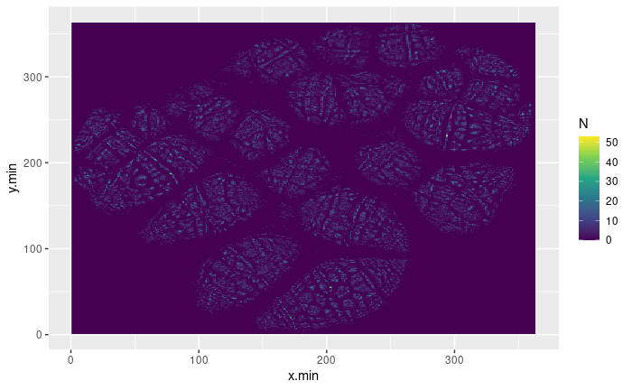

```r
rescaled_tSNE %>%
  group_by(pixel_ID) %>%
  summarise(N=n()) %>%
  right_join(pixels) %>%
  mutate(N = replace_na(N,0)) %>%
  ungroup %>%
  arrange(N) %>%
  ggplot() +
  geom_raster(aes(x=x.min,y=y.min,fill=N)) +
  scale_fill_viridis_c()
```

Now let’s move points around so that each grid cell has only one point.

First, we will fix points that are unique in a grid cell.

Next, we will fix the point closest to the midpoint of each grid cell (and randomly choosing if a tie)

Next, we will get the point closest to a midpoint that was not assigned in the first round, and will assign it to the closes free grid cell. We will repeat that until all points are assigned.

Let’s start by making a data.frame to store our results

```r
kmer_grid = rescaled_tSNE %>%
  mutate(ID=1:n()) %>%
  select(ID,x,y,complexity,AT,start_pixel = pixel_ID)
```

Let’s find IDs for kmers that are alone in a grid cell:

```r
ones = kmer_grid %>%
  group_by(start_pixel) %>%
  summarise(N=n()) %>%
  filter(N == 1) %>%
  select(start_pixel) %>%
  mutate(final_pixel = start_pixel)

kmer_grid = kmer_grid %>%
  left_join(ones)
kmer_grid
```

| ID | x | y | complexity | AT | start_pixel | final_pixel |
| --- | --- | --- | --- | --- | --- | --- |
| 1 | 147.935870 | 12.844937 | 21.95445 | 1.0000000 | 4140 | 4140 |
| 2 | 149.182273 | 13.567252 | 22.91832 | 0.8888889 | 4505 | NA |
| 3 | 149.219800 | 13.359199 | 22.91832 | 0.8888889 | 4505 | NA |
| 4 | 105.314664 | 27.488404 | 22.91832 | 1.0000000 | 9543 | 9543 |
| 5 | 150.557115 | 15.487956 | 23.62814 | 0.8888889 | 5232 | NA |
| 6 | 150.582034 | 14.248402 | 23.99124 | 0.7777778 | 4869 | NA |
| 7 | 149.952452 | 12.921379 | 24.13356 | 0.7777778 | 4142 | 4142 |
| 8 | 150.854629 | 14.333718 | 24.13356 | 0.8888889 | 4869 | NA |
| 9 | 151.365795 | 13.340470 | 23.62814 | 0.8888889 | 4507 | NA |
| 10 | 149.292114 | 14.099489 | 24.13356 | 0.7777778 | 4868 | NA |

[output cut: 990 more lines]

Now let’s assign kmers that are sharing a pixel. For each pixel, we will keep the kmer closest to the center. We will set a random seed to make tie breaks reproducible

```r
set.seed(123134)

get_dist_to_pixel = function(x,y,px){
  this_px = pixels %>%
    filter(pixel_ID == px)


  sqrt((x - this_px$x.mid)^2 +
         (y - this_px$y.mid)^2)
}


kmers_left = kmer_grid %>%
  filter(is.na(final_pixel)) %>%
  rowwise %>%
  mutate(dist_to_pixel = get_dist_to_pixel(x,y,start_pixel))


chosen_kmers = kmers_left %>%
  group_by(start_pixel) %>%
  top_n(-1, wt = dist_to_pixel) %>%
  sample_n(1) %>%
  pull(ID)

kmer_grid = kmer_grid %>%
  mutate(final_pixel = ifelse(ID %in% chosen_kmers, start_pixel,final_pixel))

kmers_left = kmers_left %>%
  filter(!(ID %in% chosen_kmers))
```

Now we will loop through remaining kmers by the distance to the closest pixel. We will then find the closest free pixel and assign it. We will continue until all kmers are assigned to a pixel. Let’s make a function first.

```r
redistribute_grid = function(kgrd, klft, pixels){
  while (nrow(klft)){ #using base r for filtering since it is faster

    assigned_px = unlist(kgrd[!is.na(kgrd$final_pixel),'final_pixel'])

    this_kmer = klft %>%
      ungroup %>%
      top_n(-1,wt= dist_to_pixel) %>%
      sample_n(1)

    this_px = pixels[!(pixels$pixel_ID %in% assigned_px),] %>%
      mutate(dist_to_this_kmer = sqrt((x.mid-this_kmer$x)^2+(y.mid-this_kmer$y)^2)) %>%
      ungroup %>%
      top_n(-1,wt= dist_to_this_kmer) %>%
      sample_n(1) %>%
      pull(pixel_ID)

    kgrd[kgrd$ID == this_kmer$ID,'final_pixel'] = this_px

    klft = klft[klft$ID != this_kmer$ID,]

    if (nrow(klft) %% 1000 == 0) message('Kmers left: ',nrow(klft))

  }
  return(kgrd)
}
```

Now let’s run it

```r
final_kmer_grid = redistribute_grid(kmer_grid,kmers_left,pixels)
```

```
Kmers left: 95000
Kmers left: 94000
Kmers left: 93000
Kmers left: 92000
Kmers left: 91000
Kmers left: 90000
Kmers left: 89000
Kmers left: 88000
Kmers left: 87000
Kmers left: 86000
Kmers left: 85000
Kmers left: 84000
Kmers left: 83000
Kmers left: 82000
Kmers left: 81000
Kmers left: 80000
Kmers left: 79000
Kmers left: 78000
Kmers left: 77000
Kmers left: 76000
Kmers left: 75000
Kmers left: 74000
Kmers left: 73000
Kmers left: 72000
Kmers left: 71000
Kmers left: 70000
Kmers left: 69000
Kmers left: 68000
Kmers left: 67000
Kmers left: 66000
Kmers left: 65000
Kmers left: 64000
Kmers left: 63000
Kmers left: 62000
Kmers left: 61000
Kmers left: 60000
Kmers left: 59000
Kmers left: 58000
Kmers left: 57000
Kmers left: 56000
```

[output cut: 41 more lines]

```
Kmers left: 14000
Kmers left: 13000
Kmers left: 12000
Kmers left: 11000
Kmers left: 10000
Kmers left: 9000
Kmers left: 8000
Kmers left: 7000
Kmers left: 6000
Kmers left: 5000
Kmers left: 4000
Kmers left: 3000
Kmers left: 2000
Kmers left: 1000
Kmers left: 0
```

```r
final_kmer_grid
```

| ID | x | y | complexity | AT | start_pixel | final_pixel |
| --- | --- | --- | --- | --- | --- | --- |
| 1 | 147.935870 | 12.844937 | 21.95445 | 1.0000000 | 4140 | 4140 |
| 2 | 149.182273 | 13.567252 | 22.91832 | 0.8888889 | 4505 | 4141 |
| 3 | 149.219800 | 13.359199 | 22.91832 | 0.8888889 | 4505 | 4505 |
| 4 | 105.314664 | 27.488404 | 22.91832 | 1.0000000 | 9543 | 9543 |
| 5 | 150.557115 | 15.487956 | 23.62814 | 0.8888889 | 5232 | 5232 |
| 6 | 150.582034 | 14.248402 | 23.99124 | 0.7777778 | 4869 | 4869 |
| 7 | 149.952452 | 12.921379 | 24.13356 | 0.7777778 | 4142 | 4142 |
| 8 | 150.854629 | 14.333718 | 24.13356 | 0.8888889 | 4869 | 3049 |
| 9 | 151.365795 | 13.340470 | 23.62814 | 0.8888889 | 4507 | 4144 |
| 10 | 149.292114 | 14.099489 | 24.13356 | 0.7777778 | 4868 | 2683 |

[output cut: 990 more lines]

Let’s now visualize the grid.

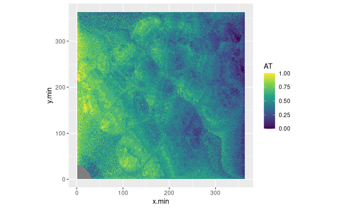

```r
final_pixels = pixels %>%
  select(x.min,y.min,final_pixel = pixel_ID) %>%
  left_join(final_kmer_grid)
ggplot(final_pixels) +
  geom_raster(aes(x=x.min,y=y.min,fill=AT)) +
  scale_fill_viridis_c() +
  coord_equal()
```

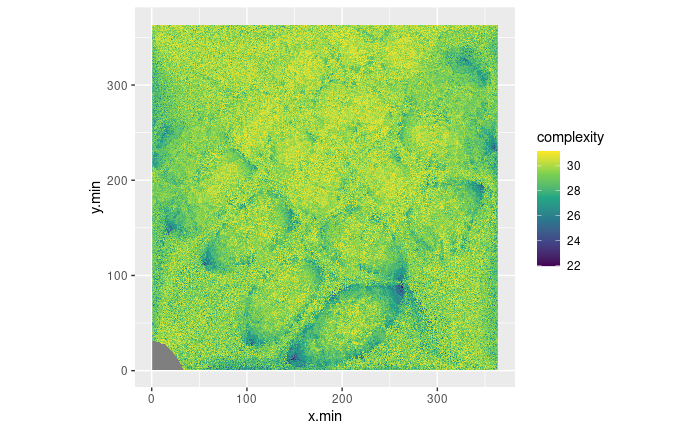

```r
ggplot(final_pixels) +
  geom_raster(aes(x=x.min,y=y.min,fill=complexity)) +
  scale_fill_viridis_c() +
  coord_equal()
```

Finally, let’s create a data frame only with the information that we will need in python:

```r
kmer_mapping = tsne_res %>%
  select(canonical) %>%
  mutate(ID=1:n()) %>%
  left_join(final_kmer_grid %>%
              select(ID,
                     pixel_ID = final_pixel)) %>%
  left_join(pixels %>%
               select(pixel_ID,
                      x=x.min,
                      y=y.min)) %>%
  select(-ends_with("ID"))
kmer_mapping %>%
  arrange(y,x)
```

| canonical | x | y |
| --- | --- | --- |
| CACTCCAGG | 33 | 1 |
| AGTTCCAGA | 34 | 1 |
| AGACAAGAG | 35 | 1 |
| AGGGACTCC | 36 | 1 |
| GCTTTGAAC | 37 | 1 |
| GGAGAGTGA | 38 | 1 |
| AAAGTGACT | 39 | 1 |
| CCAACTGTC | 40 | 1 |
| ACTTTGGAG | 41 | 1 |
| ACCTCTCCA | 42 | 1 |

[output cut: 990 more lines]

```r
NA
```

Because dsk uses a different lexicographical order from Jellyfish when deciding which is the canonical kmer, let’s add all kmers to this table to make sure.

```r
to_vec = function(str){
  purrr::map(1:nchar(str), ~substr(str,.x,.x)) %>% unlist
}

kmer_mapping2 = kmer_mapping

kmer_mapping2$canonical = purrr::map(kmer_mapping$canonical, ~to_vec(.x) %>%
             ape::as.DNAbin() %>%
             ape::complement() %>%
             as.character %>%
             unlist() %>%
             toupper() %>%
             paste0(collapse = '')
             ) %>% unlist()

kmer_mapping = rbind(kmer_mapping, kmer_mapping2)

names(kmer_mapping)[1] = 'kmer'
```

And save it as parquet for loading in VARcode.

```r
kmer_mapping
```

| kmer | x | y |
| --- | --- | --- |
| AAAAAAAAA | 147 | 12 |
| CAAAAAAAA | 148 | 12 |
| GAAAAAAAA | 149 | 13 |
| TAAAAAAAA | 105 | 27 |
| ACAAAAAAA | 150 | 15 |
| CCAAAAAAA | 150 | 14 |
| GCAAAAAAA | 149 | 12 |
| TCAAAAAAA | 145 | 9 |
| AGAAAAAAA | 151 | 12 |
| CGAAAAAAA | 142 | 8 |

[output cut: 990 more lines]

```r
write_parquet(kmer_mapping,paste0(kmer_len, 'mer_mapping.parquet'))
```